# Sliced 2021 Episode 9: Baseball home runs

John Thompson

2021-10-28 14:43:56

# Summary

# Introduction:

The data for the ninth episode of `Sliced 2021` can be downloaded from https://www.kaggle.com/c/sliced-s01e09-playoffs-1. These data contain data on each hit made during the 2020 baseball playoffs. The objective is to predict whether or not the hit resulted in a home run. Evaluation is by logloss.

# Reading the data:

It is my practice to read the data asis and to immediately save it in rds format within a directory called data/rData. For details of the way that I organise my analyses, read my post called `Sliced Methods Overview`.

```r
# --- setup: libraries & options ------------------------
library(tidyverse)

theme_set( theme_light())

# --- set home directory -------------------------------
home <- "C:/Projects/kaggle/sliced/s01-e09"

# --- read downloaded data -----------------------------
trainRawDF <- readRDS( file.path(home, "data/rData/train.rds") )

parkRawDF <- readRDS( file.path(home, "data/rData/park_dimensions.rds") )

testRawDF <- readRDS( file.path(home, "data/rData/test.rds") )
```

# Data Exploration:

As usual, I start by summarising the training data with the `skimr` package and omitting the output from this post because of its length.

```r
# --- summarise the training set -----------------------
skimr::skim(trainRawDF)
```

In summary, there were 46244 hits of which 2447 (5.3%) resulted in a home run. There is no missing data except for a handful of missing classifications of the type of hit and about 25% of the measures of the speed and angle with which the ball left the bat.

# Predictors

The first thing to note is that home runs cannot be hit off a ground ball or a pop up, which means that over half of the hits can be eliminated without further consideration.

I label the hits that do not go for a home run as ‘in field’; I have no idea whether this would make sense to baseball fans.

```r
# --- ball type and home runs -------------------------------------
trainRawDF %>%
  mutate( is_home_run = factor(is_home_run, levels=c(0,1),
                               labels=c("In_field", "Home_run"))) %>%
  count(bb_type, is_home_run) %>%
  pivot_wider( values_from=n, names_from=is_home_run, values_fill=0)
```

```
## # A tibble: 5 x 3
##   bb_type     In_field Home_run
##   <chr>          <int>    <int>
## 1 fly_ball        8383     1345
## 2 ground_ball    20197        0
## 3 line_drive     11875     1102
## 4 popup           3336        0
## 5 <NA>               6        0
```

In the following data exploration, I only consider fly balls and line drives.

### Launch angle and speed

The next most important factors are the speed and angle of the hit.

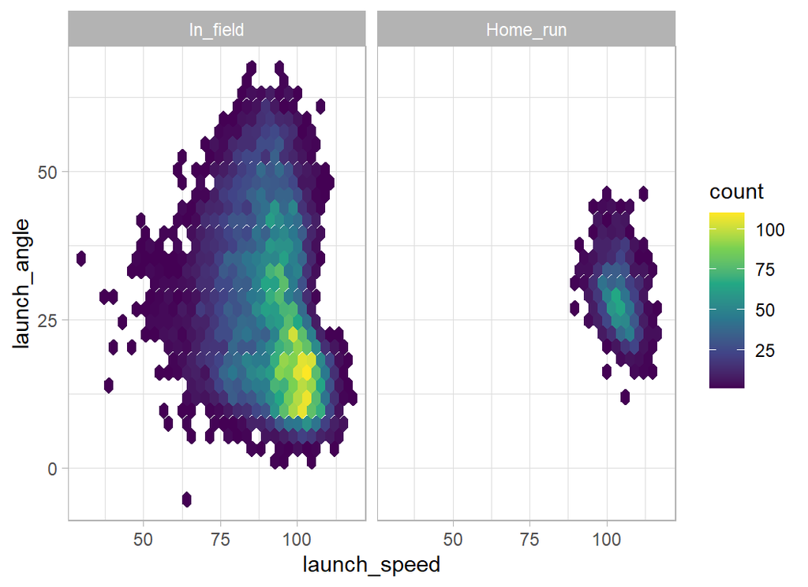

```r
# --- speed and angle of the hits ---------------------------------
trainRawDF %>%
  filter( bb_type %in% c("fly_ball", "line_drive")) %>%
  mutate( is_home_run = factor(is_home_run, levels=c(0,1),
                               labels=c("In_field", "Home_run"))) %>%
  ggplot( aes(x=launch_speed, y=launch_angle)) +
  geom_hex( bins=30) +
  scale_fill_viridis_c() +
  facet_wrap(~is_home_run)
```

Even with fly_balls and line_drives, it is impossible to hit a home run if the launch angle is over 50 degrees or under 10 degrees. The launch speed needs to be over 85 mph.

Unfortunately, launch speed and angle are often missing.

```r
# --- missing speed and angle of hit ---------------------------------
trainRawDF %>%
  filter( bb_type %in% c("fly_ball", "line_drive")) %>%
  mutate( is_home_run = factor(is_home_run, levels=c(0,1),
                               labels=c("In_field", "Home_run"))) %>%
  mutate( speed = ifelse(is.na(launch_speed), "missing", "measured"),
          angle = ifelse(is.na(launch_angle), "missing", "measured")) %>%
  group_by( speed, angle, is_home_run) %>%
  summarise( n = n(), .groups="drop") %>%
  pivot_wider( values_from=n, names_from=is_home_run) %>%
  mutate( pct = round(100*Home_run/(Home_run+In_field),1) )
```

```
## # A tibble: 4 x 5
##   speed    angle    In_field Home_run   pct
##   <chr>    <chr>       <int>    <int> <dbl>
## 1 measured measured    11465     1317  10.3
## 2 measured missing      3727      462  11
## 3 missing  measured     3709      502  11.9
## 4 missing  missing      1357      166  10.9
```

Nearly, half of all home runs have one or other or both missing, but it seems that missingness is not very informative.

### The pitch

The type of pitch is not very predictive.

```r
# --- type of pitch --------------------------------------------------
trainRawDF %>%
  filter( bb_type %in% c("fly_ball", "line_drive")) %>%
  mutate( is_home_run = factor(is_home_run, levels=c(0,1),
                               labels=c("In_field", "Home_run"))) %>%
  count( pitch_name, is_home_run) %>%
  pivot_wider( values_from=n, names_from=is_home_run, values_fill=0) %>%
  mutate( pct = round(100*Home_run/(Home_run+In_field),1) )
```

```
## # A tibble: 9 x 4
##   pitch_name      In_field Home_run   pct
##   <chr>              <int>    <int> <dbl>
## 1 4-Seam Fastball     7643     1014  11.7
## 2 Changeup            2423      263   9.8
## 3 Curveball           1506      177  10.5
## 4 Cutter              1478      170  10.3
## 5 Forkball               1        0   0
## 6 Knuckle Curve        345       41  10.6
## 7 Sinker              3339      360   9.7
## 8 Slider              3203      385  10.7
## 9 Split-Finger         320       37  10.4
```

Nor is the speed of the pitch

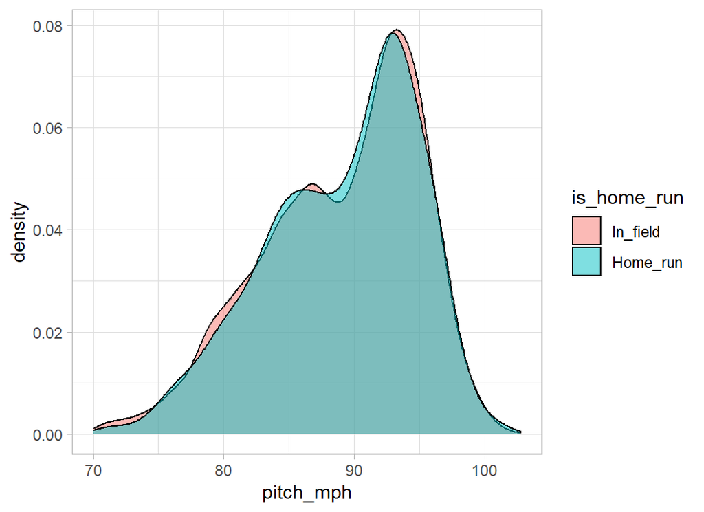

```r
# --- pitch speed ----------------------------------------------------
trainRawDF %>%
  filter( bb_type %in% c("fly_ball", "line_drive")) %>%
  mutate( is_home_run = factor(is_home_run, levels=c(0,1),
                               labels=c("In_field", "Home_run"))) %>%
  ggplot( aes(x=pitch_mph, fill=is_home_run)) +
  geom_density( alpha=0.5)
```

### Position in the hit zone

The position of the pitch in the hitting zone is important, anything central can go for a home run, but not those pitches on the edge of the zone.

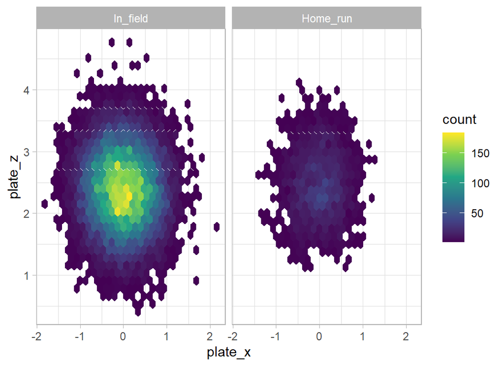

```r
# --- position in the hit zone ---------------------------------------
trainRawDF %>%
  filter( bb_type %in% c("fly_ball", "line_drive")) %>%
  mutate( is_home_run = factor(is_home_run, levels=c(0,1),
                               labels=c("In_field", "Home_run"))) %>%
  ggplot( aes(x=plate_x, y=plate_z)) +
  geom_hex( bins=30) +
  scale_fill_viridis_c() +
  facet_wrap(~is_home_run)
```

It is important to check whether the batter is right or left-handed

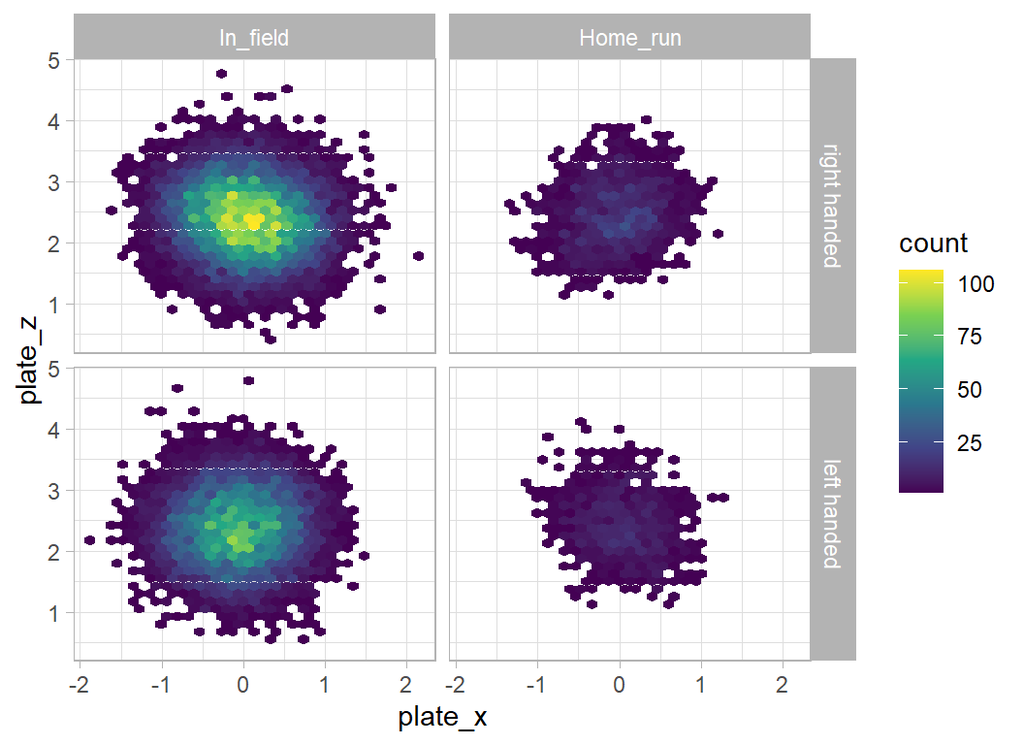

```r
# --- position in the hit zone ---------------------------------------
trainRawDF %>%
  filter( bb_type %in% c("fly_ball", "line_drive")) %>%
  mutate( is_home_run = factor(is_home_run, levels=c(0,1),
                               labels=c("In_field", "Home_run"))) %>%
  mutate( is_batter_lefty = factor(is_batter_lefty, levels=0:1,
                               labels=c("right handed", "left handed"))) %>%
  ggplot( aes(x=plate_x, y=plate_z)) +
  geom_hex( bins=30) +
  scale_fill_viridis_c() +
  facet_grid(is_batter_lefty ~ is_home_run)
```

There is a sloping line that goes along a different diagonal for home runs hit by right and left handed batters, but the difference is hardly predictive.

### Direction of the hit

I assume that the bearing refers to the direction of the hit relative to the plate. In which case it is again important to distinguish left and right-handed batters.

```r
# --- direction of the hit ----------------------------------------
trainRawDF %>%
  filter( bb_type %in% c("fly_ball", "line_drive")) %>%
  mutate( is_home_run = factor(is_home_run, levels=c(0,1),
                               labels=c("In_field", "Home_run"))) %>%
  mutate( is_batter_lefty = factor(is_batter_lefty, levels=0:1,
                               labels=c("right handed", "left handed"))) %>%
  count( is_batter_lefty, bearing, is_home_run) %>%
  pivot_wider( values_from=n, names_from=is_home_run, values_fill=0) %>%
  mutate( pct = round(100*Home_run/(Home_run+In_field),1) )
```

```
## # A tibble: 6 x 5
##   is_batter_lefty bearing In_field Home_run   pct
##   <fct>           <chr>      <int>    <int> <dbl>
## 1 right handed    center      4305      953  18.1
## 2 right handed    left        3482      434  11.1
## 3 right handed    right       3909      109   2.7
## 4 left handed     center      3241      567  14.9
## 5 left handed     left        2993       53   1.7
## 6 left handed     right       2328      331  12.4
```

Most home runs are hit to centre field. Right-handers rarely hit home runs to the right and left-handers rarely hit them to the left. It seems to be like cricket, where it is much harder to hit a six over the off-side.

### State of play

The state of play seems to have a slight impact. Perhaps batters are more likely to go after the pitch when they are ahead of the pitcher, 3-0, 2-0 or 3-1

```r
# --- balls and strikes ------------------------------------------------
trainRawDF %>%
  filter( bb_type %in% c("fly_ball", "line_drive")) %>%
  mutate( is_home_run = factor(is_home_run, levels=c(0,1),
                               labels=c("In_field", "Home_run"))) %>%
  count( balls, strikes, is_home_run) %>%
  pivot_wider( values_from=n, names_from=is_home_run, values_fill=0) %>%
  mutate( difference = balls - strikes ) %>%
  mutate( pct = round(100*Home_run/(Home_run+In_field),1) ) %>%
  arrange(pct) %>%
  select( balls, strikes, difference, In_field, Home_run, pct)
```

```
## # A tibble: 12 x 6
##    balls strikes difference In_field Home_run   pct
##    <dbl>   <dbl>      <dbl>    <int>    <int> <dbl>
##  1     0       2         -2     1305      108   7.6
##  2     1       2         -1     2279      220   8.8
##  3     0       1         -1     2460      248   9.2
##  4     2       2          0     2338      260  10
##  5     3       2          1     1895      218  10.3
##  6     1       1          0     2277      279  10.9
##  7     2       1          1     1368      171  11.1
##  8     0       0          0     3112      417  11.8
##  9     1       0          1     1798      266  12.9
## 10     3       1          2      660      114  14.7
## 11     2       0          2      711      126  15.1
## 12     3       0          3       55       20  26.7
```

The difference (balls minus strikes) seems to be predictive but, the number of outs is not very predictive.

```r
# --- number of outs -----------------------------------------------
trainRawDF %>%
  filter( bb_type %in% c("fly_ball", "line_drive")) %>%
  mutate( is_home_run = factor(is_home_run, levels=c(0,1),
                               labels=c("In_field", "Home_run"))) %>%
  count( outs_when_up, is_home_run) %>%
  pivot_wider( values_from=n, names_from=is_home_run, values_fill=0) %>%
  mutate( pct = round(100*Home_run/(Home_run+In_field),1) )
```

```
## # A tibble: 3 x 4
##   outs_when_up In_field Home_run   pct
##          <dbl>    <int>    <int> <dbl>
## 1            0     7224      930  11.4
## 2            1     6653      783  10.5
## 3            2     6381      734  10.3
```

### Batter’s team

Obviously some teams are better at batting than others.

```r
# --- batter's team ----------------------------------------------
trainRawDF %>%
  filter( bb_type %in% c("fly_ball", "line_drive")) %>%
  mutate( is_home_run = factor(is_home_run, levels=c(0,1),
                               labels=c("In_field", "Home_run"))) %>%
  count( batter_team, is_home_run) %>%
  pivot_wider( values_from=n, names_from=is_home_run, values_fill=0) %>%
  mutate( pct = round(100*Home_run/(Home_run+In_field),1) ) %>%
  arrange( desc(pct)) %>%
  print(n = 30)
```

```
## # A tibble: 30 x 4
##    batter_team In_field Home_run   pct
##    <chr>          <int>    <int> <dbl>
##  1 CWS              637      101  13.7
##  2 NYY              685      109  13.7
##  3 LAD              941      145  13.4
##  4 TB               736      114  13.4
##  5 SD               701      103  12.8
##  6 CIN              630       90  12.5
##  7 ATL              847      119  12.3
##  8 NYM              631       86  12
##  9 MIN              677       91  11.8
## 10 CHC              564       74  11.6
## 11 LAA              669       85  11.3
## 12 TOR              692       88  11.3
```

[output cut: 18 more lines]

### Pitcher’s team

Some teams are better at pitching

```r
# --- pitcher's team -----------------------------------------------
trainRawDF %>%
  filter( bb_type %in% c("fly_ball", "line_drive")) %>%
  mutate( is_home_run = factor(is_home_run, levels=c(0,1),
                               labels=c("In_field", "Home_run"))) %>%
  mutate( pitcher_team = ifelse( batter_team == home_team, away_team,
                                 home_team)) %>%
  count( pitcher_team, is_home_run) %>%
  pivot_wider( values_from=n, names_from=is_home_run, values_fill=0) %>%
  mutate( pct = round(100*Home_run/(Home_run+In_field),1) ) %>%
  arrange( desc(pct)) %>%
  print(n = 30)
```

```
## # A tibble: 30 x 4
##    pitcher_team In_field Home_run   pct
##    <chr>           <int>    <int> <dbl>
##  1 BOS               687       97  12.4
##  2 NYY               663       94  12.4
##  3 PHI               593       80  11.9
##  4 DET               682       91  11.8
##  5 ARI               705       93  11.7
##  6 PIT               608       80  11.6
##  7 WSH               710       93  11.6
##  8 NYM               628       81  11.4
##  9 STL               577       74  11.4
## 10 HOU               735       93  11.2
## 11 MIL               537       68  11.2
## 12 TOR               660       83  11.2
```

[output cut: 18 more lines]

### Team comparison

I combine the batting and pitching percentages of home runs so as to create an overall comparison between teams.

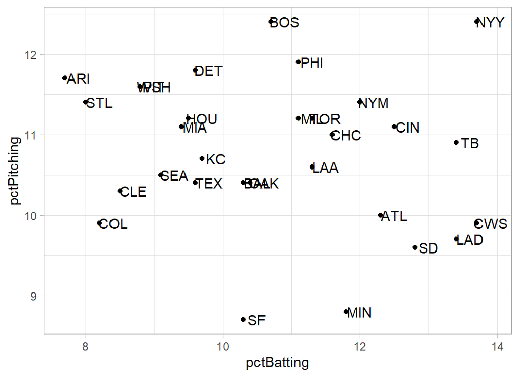

```r
# --- batting percentages -------------------------------------------
trainRawDF %>%
  filter( bb_type %in% c("fly_ball", "line_drive")) %>%
  mutate( is_home_run = factor(is_home_run, levels=c(0,1),
                               labels=c("In_field", "Home_run"))) %>%
  count( batter_team, is_home_run) %>%
  pivot_wider( values_from=n, names_from=is_home_run, values_fill=0) %>%
  mutate( pctBatting = round(100*Home_run/(Home_run+In_field),1) ) %>%
  rename( team = batter_team ) %>%
  select( team, pctBatting ) -> batDF

# --- pitching percentages ------------------------------------------
trainRawDF %>%
  filter( bb_type %in% c("fly_ball", "line_drive")) %>%
  mutate( is_home_run = factor(is_home_run, levels=c(0,1),
                               labels=c("In_field", "Home_run"))) %>%
  mutate( pitcher_team = ifelse( batter_team == home_team, away_team, home_team)) %>%
  count( pitcher_team, is_home_run) %>%
  pivot_wider( values_from=n, names_from=is_home_run, values_fill=0) %>%
  mutate( pctPitching = round(100*Home_run/(Home_run+In_field),1) ) %>%
  rename( team = pitcher_team ) %>%
  select( team, pctPitching ) -> pitDF

# --- team statistics -----------------------------------------------
batDF %>%
  left_join( pitDF, by = "team") %>%
  ggplot( aes(x=pctBatting, y=pctPitching, label=team)) +
  geom_point() +
  geom_text(nudge_x=0.2)
```

New York Yankees must be good to watch, they hit a lot of home runs and they give up a lot of home runs. Minesotta and San Francisco are good pitching teams. The best teams are in the bottom right of the plot and we should all feel sorry for the fans of Arizona.

If these data do refer to 2020 then Tampa Bay Rays (TB) played the LA Dodgers (LAD) in the final (bizarrely called the world series) and the Dodgers won. This would fit with the plot.

### Home advantage

Slightly more home runs are hit by home teams

```r
trainRawDF %>%
  filter( bb_type %in% c("fly_ball", "line_drive")) %>%
  mutate( is_home_run = factor(is_home_run, levels=c(0,1),
                               labels=c("In_field", "Home_run"))) %>%
  mutate( pitcher_team = ifelse( batter_team == home_team, away_team, home_team)) %>%
  mutate( at_home = factor(batter_team == home_team, levels=c(FALSE, TRUE),
                           labels=c("Away", "Home"))) %>%
  count( at_home, is_home_run) %>%
  pivot_wider( values_from=n, names_from=is_home_run, values_fill=0) %>%
  mutate( pct = round(100*Home_run/(Home_run+In_field),1) ) %>%
  arrange( desc(pct)) %>%
  print()
```

```
## # A tibble: 2 x 4
##   at_home In_field Home_run   pct
##   <fct>      <int>    <int> <dbl>
## 1 Home        9896     1252  11.2
## 2 Away       10362     1195  10.3
```

## Baseball park

Unfortunately the park datafile does not include the name of the team that plays there. To make matters worse, some of the stadiums appear to have changed their names. To the best of my knowledge (by which I mean Google) I have matched teams to the stadiums.

```r
teams <- c("LAA", "STL", "ARI", "NYM", "PHI", "DET", "COL",
           "LAD", "BOS", "TEX", "CIN", "CWS", "KC" , "MIA",
           "MIL", "HOU", "WSH", "NYY", "SF",  "BAL", "SD",
           "PIT", "CLE", "OAK", "TOR", "ATL", "SEA", "MIN",
           "TB",  "CHC")

parkRawDF %>%
  arrange(NAME) %>%
  mutate(home_team = teams)  -> parkDF

parkDF %>%
  select(NAME, home_team) %>%
  print()
```

```
## # A tibble: 30 x 2
##    NAME                     home_team
##    <chr>                    <chr>
##  1 Angel Stadium of Anaheim LAA
##  2 Busch Stadium III        STL
##  3 Chase Field              ARI
##  4 Citi Field               NYM
##  5 Citizens Bank Park       PHI
##  6 Comerica Park            DET
##  7 Coors Field              COL
##  8 Dodger Stadium           LAD
##  9 Fenway Park              BOS
## 10 Globe Life Park          TEX
## # ... with 20 more rows
```

Now I can calculate the percentage of home runs hit in each stadium.

```r
# --- baseball parks -------------------------------------------------
trainRawDF %>%
  left_join( parkDF, by = "home_team") %>%
  filter( bb_type %in% c("fly_ball", "line_drive")) %>%
  mutate( is_home_run = factor(is_home_run, levels=c(0,1),
                               labels=c("In_field", "Home_run"))) %>%
  count( NAME, is_home_run) %>%
  pivot_wider( values_from=n, names_from=is_home_run, values_fill=0) %>%
  mutate( pct = round(100*Home_run/(Home_run+In_field),1) ) %>%
  arrange( desc(pct)) %>%
  print(n = 30)
```

```
## # A tibble: 30 x 4
##    NAME                        In_field Home_run   pct
##    <chr>                          <int>    <int> <dbl>
##  1 Great American Ballpark          538      107  16.6
##  2 New Yankee Stadium               697      113  14
##  3 Guarantee Rate Park              585       91  13.5
##  4 Citi Field                       613       93  13.2
##  5 Petco Park                       673       98  12.7
##  6 Citizens Bank Park               652       92  12.4
##  7 Tropicana Field                  760      108  12.4
##  8 Miller Park                      549       76  12.2
##  9 Angel Stadium of Anaheim         705       96  12
## 10 Dodger Stadium                   929      126  11.9
## 11 SunTrust Park                    809      104  11.4
## 12 Fenway Park                      721       89  11
```

[output cut: 18 more lines]

The big question is whether these differences are due to the size of the park or the team that plays there.

The length of hit needed for a home run depends on the dimensions of the park and the size of the wall that you have to hit over. These will vary between the centre, left and right of the park. I have created a crude overall measure by adding the distance to the height of the wall and then averaging over the three directions.

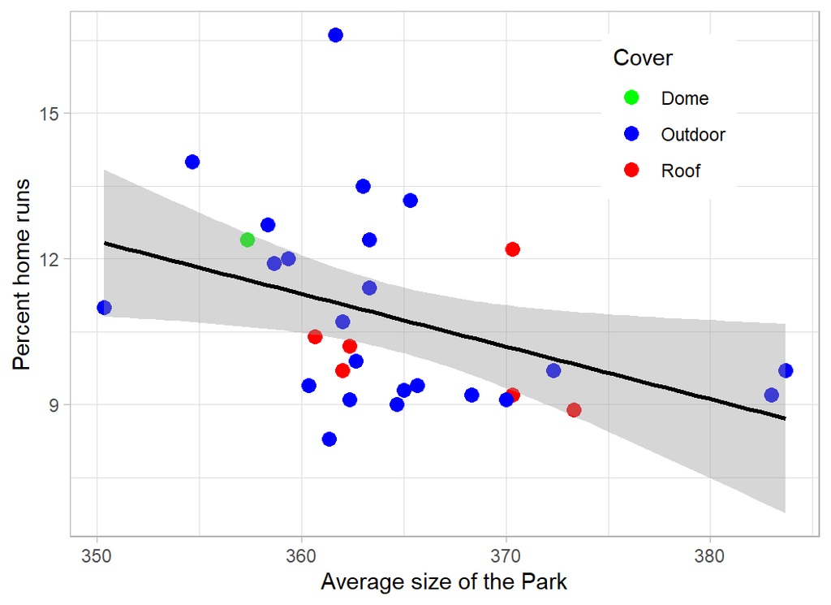

```r
# --- park dimensions ------------------------------------------------]
trainRawDF %>%
  filter( bb_type %in% c("fly_ball", "line_drive")) %>%
  mutate( is_home_run = factor(is_home_run, levels=c(0,1),
                               labels=c("In_field", "Home_run"))) %>%
  count( home_team, is_home_run) %>%
  pivot_wider( values_from=n, names_from=is_home_run, values_fill=0) %>%
  mutate( pct = round(100*Home_run/(Home_run+In_field),1) ) %>%
  left_join( parkDF, by = "home_team") %>%
  mutate( size = (LF_Dim + LF_W + CF_Dim + CF_W + RF_Dim + RF_W)/3 ) %>%
  ggplot( aes(x=size, y=pct, colour=Cover)) +
  geom_point( size=3) +
  geom_smooth( colour="Black", method="lm") +
  scale_colour_manual(values=c("Green", "Blue", "Red")) +
  labs(y="Percent home runs", x="Average size of the Park") +
  theme( legend.position = c(0.8, 0.8))
```

The trend of more home runs in smaller parks is there but it is weak.

# Predictive Model

5.3% of all hits end in a home run

```r
# --- home runs in all hits -----------------------------------------
trainRawDF %>%
  mutate( is_home_run = factor(is_home_run, levels=c(0,1),
                               labels=c("In_field", "Home_run"))) %>%
  count( is_home_run ) %>%
  mutate( pct = 100*n/sum(n))
```

```
## # A tibble: 2 x 3
##   is_home_run     n   pct
##   <fct>       <int> <dbl>
## 1 In_field    43797 94.7
## 2 Home_run     2447  5.29
```

```r
# --- home runs of eligible hits ------------------------------------
trainRawDF %>%
  filter( bb_type %in% c("fly_ball", "line_drive")) %>%
  filter( launch_speed > 85 | is.na(launch_speed) ) %>%
  filter( (launch_angle > 10 & launch_angle < 50) |
            is.na(launch_angle)) %>%
  mutate( is_home_run = factor(is_home_run, levels=c(0,1),
                               labels=c("In_field", "Home_run"))) %>%
  count( is_home_run )
```

```
## # A tibble: 2 x 2
##   is_home_run     n
##   <fct>       <int>
## 1 In_field    14326
## 2 Home_run     2447
```

This creates a very simple model, P(home run) = 0.0001 for the impossible cases and 0.14589 for the remainder. I submit this model, not because it is a good model, but because it will give me a feel as to how much I need improve.

# First submission

I apply the crude rule based on type of hit, angle and speed to the test data.

```r
# --- two-level model ---------------------------------------------
testRawDF %>%
  mutate( possible = bb_type %in% c("fly_ball", "line_drive")) %>%
  mutate( possible = possible &
            (launch_speed > 85 | is.na(launch_speed)) ) %>%
  mutate( possible = possible & (
    (launch_angle > 10 & launch_angle < 50) | is.na(launch_angle))) %>%
  mutate( is_home_run = 0.0001 * (possible==FALSE) +
                        0.14589 * (possible==TRUE) ) %>%
  select(bip_id, is_home_run) %>%
  write_csv( file.path(home, "temp/submisssion1.csv"))
```

When submitted, this simple model scores a mean logloss of 0.14556, which would put it in 20th place. To be competitive we need to reduce the loss to 0.08.

# Improved predictive model

I’ll use XGBoost for the predictive model and implement it as in episode 7, except that this time I’ll use cross-validation rather than a validation data set.

First I prepare the data

```r
# --- feature extraction: training set --------------------------
trainRawDF %>%
  mutate( possible = as.numeric(bb_type %in% c("fly_ball", "line_drive")),
          fly = as.numeric(bb_type == "fly_ball"),
          drive = as.numeric(bb_type == "line_drive")) %>%
  mutate( at_home = as.numeric(batter_team == home_team)) %>%
  mutate( pitcher_team = ifelse( batter_team == home_team,
                                 away_team, home_team)) %>%
  left_join( pitDF %>%
               rename(pitcher_team = team), by= "pitcher_team") %>%
  left_join( batDF %>%
               rename(batter_team = team), by= "batter_team") %>%
  mutate( centre = as.numeric(bearing == "center"),
          onside = as.numeric(bearing== "left" & is_batter_lefty==0 |
                          bearing=="right" & is_batter_lefty==1),
          offside = as.numeric(bearing== "left" & is_batter_lefty==1 |
                          bearing=="right" & is_batter_lefty==0) ) %>%
  left_join( parkDF, by = "home_team") %>%
  mutate( size = (LF_Dim + LF_W)*(bearing=="left") +
            (CF_Dim + CF_W)*(bearing=="center") +
            (RF_Dim + RF_W)*(bearing=="right") ) %>%
  saveRDS( file.path(home, "data/rData/prcessed_train.rds"))

# --- feature extraction: test set ----------------------------
testRawDF %>%
  mutate( possible = as.numeric(bb_type %in% c("fly_ball", "line_drive")),
          fly = as.numeric(bb_type == "fly_ball"),
          drive = as.numeric(bb_type == "line_drive")) %>%
  mutate( at_home = as.numeric(batter_team == home_team)) %>%
  mutate( pitcher_team = ifelse( batter_team == home_team, away_team, home_team)) %>%
  left_join( pitDF %>%
               rename(pitcher_team = team), by= "pitcher_team") %>%
  left_join( batDF %>%
               rename(batter_team = team), by= "batter_team") %>%
  mutate( centre = as.numeric(bearing == "center"),
          onside = as.numeric(bearing== "left" & is_batter_lefty==0 |
                          bearing=="right" & is_batter_lefty==1),
          offside = as.numeric(bearing== "left" & is_batter_lefty==1 |
                          bearing=="right" & is_batter_lefty==0) ) %>%
  left_join( parkDF, by = "home_team") %>%
  mutate( size = (LF_Dim + LF_W)*(bearing=="left") +
            (CF_Dim + CF_W)*(bearing=="center") +
            (RF_Dim + RF_W)*(bearing=="right") ) %>%
  saveRDS( file.path(home, "data/rData/prcessed_test.rds"))
```

I subjectively select what I expect to be important features and fit the model using 10-fold cross-validation. All of the hyperparameters are left at their default values.

```r
library(xgboost)

trainDF <- readRDS(file.path(home, "data/rData/prcessed_train.rds"))
testDF  <- readRDS(file.path(home, "data/rData/prcessed_test.rds"))

# --- select the training data ----------------------------
trainDF %>%
  select( fly, drive, launch_angle, launch_speed, plate_x, plate_z,
          is_batter_lefty, balls, strikes, at_home, pctBatting, pctPitching,
          centre, onside, offside, size) %>%
  as.matrix() -> X

trainDF %>%
  pull(is_home_run) -> Y

dtrain <- xgb.DMatrix(data = X, label = Y)

set.seed(4107)
# --- cross-validate the xgboost model -----------------------------
xgb.cv(data=dtrain,
       objective="binary:logistic", metrics="logloss",
       nrounds=100,
       nfold=10,
       print_every_n = 50) -> xgcv
```

The minimum value of the cross-validated logloss was 0.0884193, which occurred after 41 iterations. We can visualise the change in the logloss by using the data returned in xgcv$evaluation_log

Here is a plot of the cross-validated performance. The red line in the cross-validated logloss within its two standard deviation interval and the blue line is the in-sample logloss.

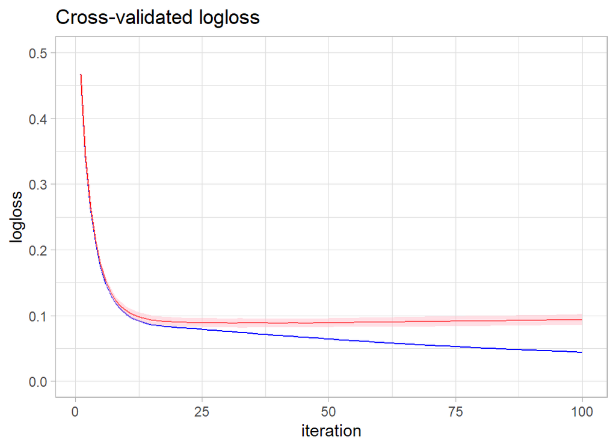

```r
xgcv$evaluation_log %>%
  as_tibble() %>%
  ggplot( aes(x=iter, y=train_logloss_mean)) +
  geom_line( colour="blue") +
  geom_line( aes(y=test_logloss_mean), colour="red") +
  geom_ribbon( aes(ymin=test_logloss_mean-2*test_logloss_std,
                   ymax=test_logloss_mean+2*test_logloss_std),
               fill="pink", alpha=0.5) +
  labs(x="iteration", y="logloss",
       title="Cross-validated logloss") +
  scale_y_continuous(limits=c(0, 0.5))
```

The best performance comes at around 30-40 iterations.

### Second submission

I’ll create a submission by refitting the model with 35 iterations.

```r
# --- fit the model ----------------------------------------
xgboost(data=X, label=Y, nrounds=35, verbose=0,
        objective="binary:logistic") -> xgmod

testDF %>%
  select( fly, drive, launch_angle, launch_speed, plate_x, plate_z,
          is_batter_lefty, balls, strikes, at_home, pctBatting, pctPitching,
          centre, onside, offside, size) %>%
  as.matrix() -> XT

# --- make predictions and save ----------------------------
testRawDF %>%
  mutate( is_home_run = predict(xgmod, newdata=XT ) ) %>%
  select(bip_id, is_home_run) %>%
  write_csv( file.path(home, "temp/submission2.csv") )
```

This default XGBoost model has a submission logloss of 0.08130, which places it in second place on the private leaderboard, very close to the leading model that scored 0.08115.

Had I chosen 40 rounds rather than 35 the submission logloss would have been 0.08120 still second but even closer to the leader. Looking at the plot of test logloss there is no way to distinguish between 30, 35, 40 or even 50 rounds, so the position on the leaderboard depends on an arbitrary decision and is thus rather meaningless.

The arbitrariness of the leaderboard is even more evident when you consider that the test set that was randomly selected by the organisers and it happens to give a much smaller logloss than the training set’s cross-validation. There is a strong degree of randomness induced by the selection of the test data. If the organisers had used a different random seed when splitting the test and training data, someone else might have won the competition.

# Let’s win (just for fun)

I know from my experience of xgboost in earlier episodes of *Sliced* that reducing the learning rate `eta` will give us a small improvement in performance at the expense of run-time. Also, I have found that the default `max_depth` of six is generally too large. We do have quite a large data set, so I am not too concerned by `max_depth`, but I will bring it down slightly.

I am bound to need more iterations, so I’ll try 500.

```r
set.seed(8337)
# --- cross-validate the xgboost model -----------------------------
xgb.cv(data=dtrain,
       objective="binary:logistic", metrics="logloss",
       eta = 0.1, max_depth=4,
       nrounds=500,
       nfold=10,
       print_every_n = 50) -> xgcv
```

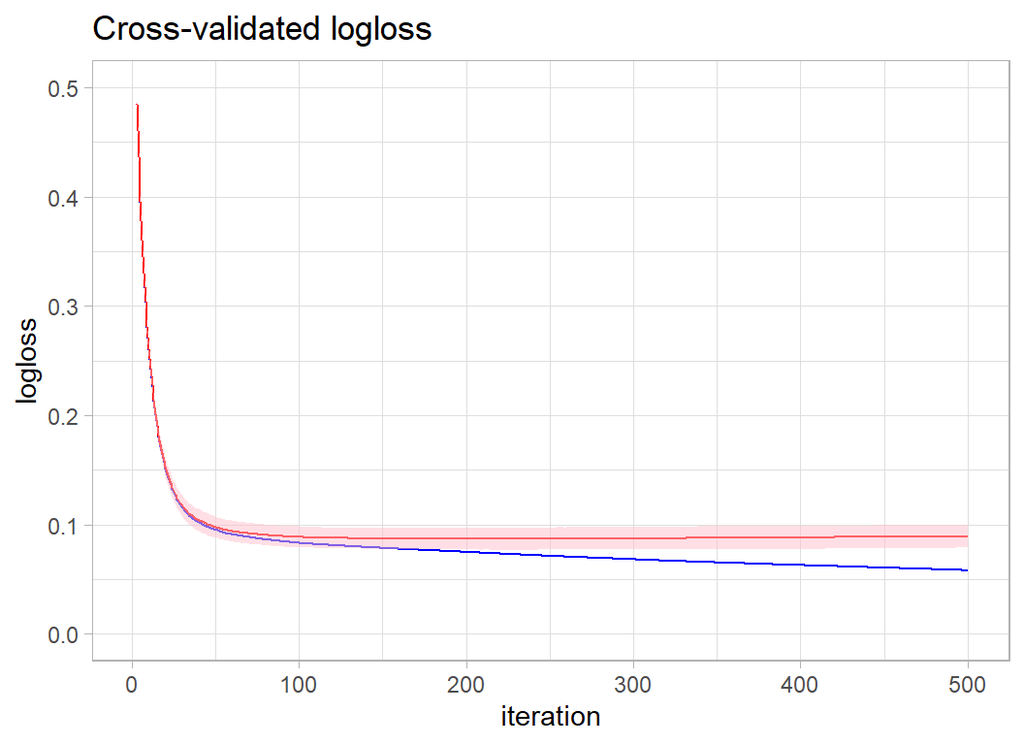

```r
xgcv$evaluation_log %>%
  as_tibble() %>%
  ggplot( aes(x=iter, y=train_logloss_mean)) +
  geom_line( colour="blue") +
  geom_line( aes(y=test_logloss_mean), colour="red") +
  geom_ribbon( aes(ymin=test_logloss_mean-2*test_logloss_std,
                   ymax=test_logloss_mean+2*test_logloss_std),
               fill="pink", alpha=0.5) +
  labs(x="iteration", y="logloss",
       title="Cross-validated logloss") +
  scale_y_continuous(limits=c(0, 0.5))
```

```r
# --- fit the model ----------------------------------------
xgboost(data=X, label=Y, nrounds=250, eta=0.1, max_depth=4,
        verbose=0,
        objective="binary:logistic") -> xgmod


# --- make predictions and save ----------------------------
testRawDF %>%
  mutate( is_home_run = predict(xgmod, newdata=XT ) ) %>%
  select(bip_id, is_home_run) %>%
  write_csv( file.path(home, "temp/submission3.csv") )
```

Unfortunately it is all rather meaningless.

# What we learn from this analysis

For me this was an interesting dataset. I am a big sports fan and although I have only ever been to watch two baseball games, one in Denver and one in Baltimore, I know that it is a fine game with a rich tradition of statistics.

The data make a fair example for a machine learning contest, provided that you know something about the sport, but perhaps the organisers should have removed the ground balls and pop ups.

Perhaps the biggest lesson is that small differences in logloss are meaningless and therefore that the ranking provided by the leaderboard is only a rough guide to model quality. *Sliced* is fun, but like any good sport, it involves an element of luck. In creating a model, the analyst makes countless close decisions that cannot really be justified; those arbitrary decisions translate into small changes in the loss and so into a higher or lower position on the leaderboard. What is worse, the test/training split made by the organisers is itself random; a different split could result in a very different looking leaderboard.

My advice is, don’t take the *Sliced* leaderboard too seriously and don’t get obsessive about hyperparameter tuning.